# Nelson (2016): Evidence for Risk-Taking

2017-November -16

## Published evidence on differences

- Croson & Gneezy (2009) argued for several differences in preferences across genders, but caveats:
  - women were more variable than men and
  - women more responsive to cues/design than men
- Gneezy & List (2012) says there's even more evidence for gender differences in risk-taking
- Nelson (2016) says these risk-taking differences are basically *negligible* and don't pay sufficient attention to *distribution*

## What does "difference" mean?

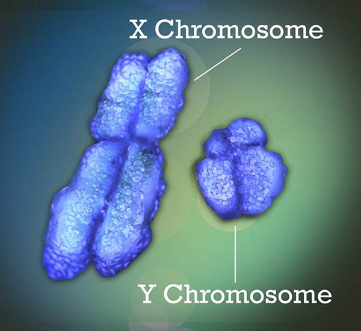

## GDI: Individual

- GDI: Gender difference at the individual level
  - *categorical* difference between men & women
  - X/Y chromosomal differences by sex (biological difference)
  - what about social/cultural differences? hair length/clothing?

## GDI: Individual?

[figure not shown]

## GDA Aggregate?

- GDA: Gender difference at the aggregate level
  - difference at aggregate, group, or distributional level,
  - such as a difference between men’s and women’s average x values
- Explanation?
  - smaller cross-group difference (\(\bar{X_M} - \bar{X_F}\)),
  - the larger the variability or spread within each group \(Var(M)\) and \(Var(F)\)
  - \(\Rightarrow\) more overlap
  - less the GDA \(\rightarrow\) GDI

## GDA Aggregate?

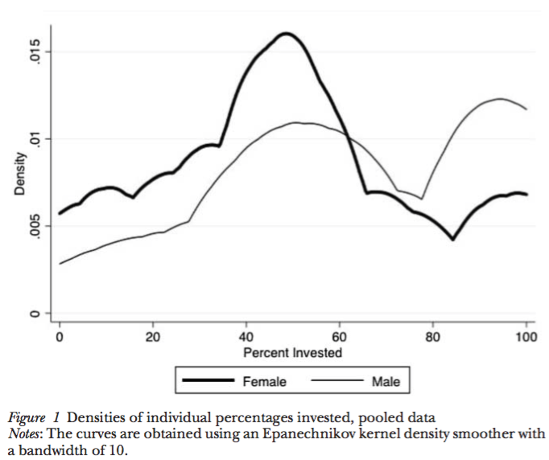

## Ways to assess? Cohen's d:

\[d = \frac{\bar{X_m} - \bar{X_f}}{\sigma_{pooled}} \]

- \(\bar{X_m}\) Male average
- \(\bar{X_f}\) Female average
- \(\sigma_{pooled}\) pooled standard deviation (within-group variation)
- Also use "Common Language Effect Size (CLEF)":
  - probability a randomly chosen man would score higher than a randomly chosen woman

## Interpretation

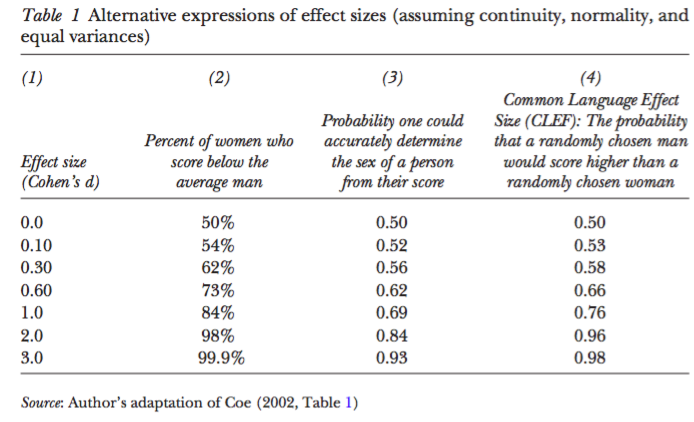

## Results?

Nelson looks at the original data in Gneezy & List (2012):

- majority of differences found have confidence interval (CI) including \(d = 0\)
- few have CI including \(d = 2\)
- none have CI including \(d = 3\)
- take-home messages?
  - be careful when talking about difference
  - present distribution figures